# Lecture 101 (draft)

2022-09-24

## Introduction to R

## About this module

This module will provide you with the fundamental skills in

- basic programming in R
- data wrangling
- data analysis
- reproducibility

basis for

- *Geospatial Data Analysis*
- *Geospatial Databases and Information Retrieval*

## R programming language

One of the most widely used programming languages and an effective tool for *(geospatial)* data science

- data wrangling
- statistical analysis
- machine learning
- data visualisation and maps
- processing spatial data
- geographic information analysis

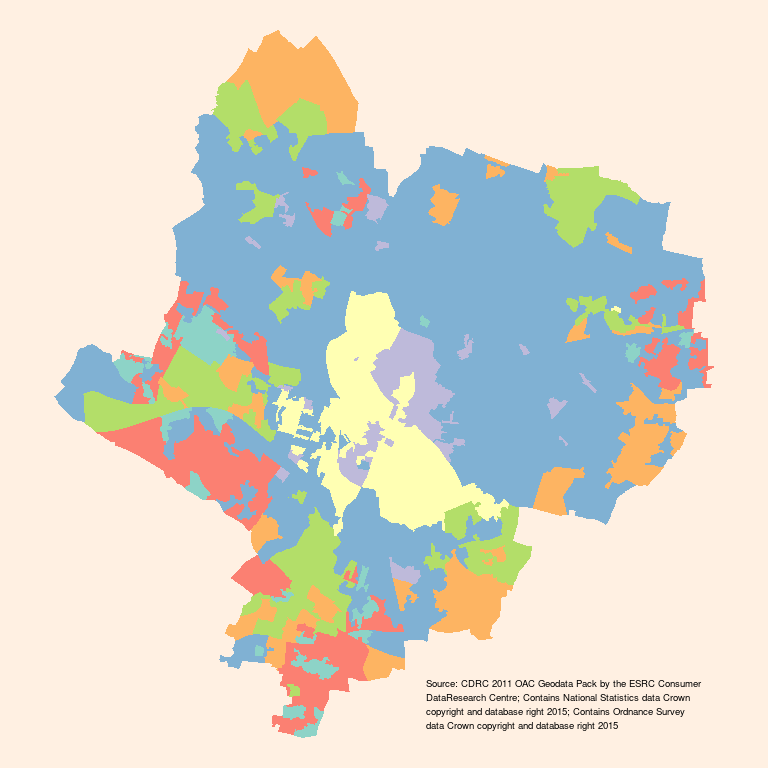

## Schedule

The lectures and practical sessions have been designed to follow the schedule below

- **1 R coding**
  - 100 Introduction
  - 110 R programming
- **2 Data wrangling**
  - 200 Selection and manipulation
  - 210 Table operations
  - 220 Reproducibility
- **3 Data analysis**
  - 300 Exploratory data analysis
  - 310 Comparing data
  - 320 Regression models
- **4 Machine learning**
  - 400 Unsupervised
  - 410 Supervised

## Reference books

Suggested reading

- *Programming Skills for Data Science: Start Writing Code to Wrangle, Analyze, and Visualize Data with R* by Michael Freeman and Joel Ross, Addison-Wesley, 2019. See book [webpage](https://www.pearson.com/us/higher-education/program/Freeman-Programming-Skills-for-Data-Science-Start-Writing-Code-to-Wrangle-Analyze-and-Visualize-Data-with-R/PGM2047488.html) and [repository](https://programming-for-data-science.github.io/).
- *R for Data Science* by Garrett Grolemund and Hadley Wickham, O’Reilly Media, 2016. See [online book](https://r4ds.had.co.nz/).
- *Discovering Statistics Using R* by Andy Field, Jeremy Miles and Zoë Field, SAGE Publications Ltd, 2012. See book [webpage](https://www.discoveringstatistics.com/books/discovering-statistics-using-r/).
- *Machine Learning with R: Expert techniques for predictive modeling* by Brett Lantz, Packt Publishing, 2019. See book [webpage](https://subscription.packtpub.com/book/big_data_and_business_intelligence/9781788295864).

Further reading

- *The Art of R Programming: A Tour of Statistical Software Design* by Norman Matloff, No Starch Press, 2011. See book [webpage](https://nostarch.com/artofr.htm)
- *An Introduction to R for Spatial Analysis and Mapping* by Chris Brunsdon and Lex Comber, Sage, 2015. See book [webpage](https://uk.sagepub.com/en-gb/eur/an-introduction-to-r-for-spatial-analysis-and-mapping/book241031)
- *Geocomputation with R* by Robin Lovelace, Jakub Nowosad, Jannes Muenchow, CRC Press, 2019. See [online book](https://bookdown.org/robinlovelace/geocompr/).

## R

Created in 1992 by Ross Ihaka and Robert Gentleman at the University of Auckland, New Zealand

- Free, open-source implementation of *S*
  - statistical programming language
  - Bell Labs
- Functional programming language
- Supports (and commonly used as) procedural (i.e., imperative) programming
- Object-oriented
- Interpreted (not compiled)

## Interpreting values

When values and operations are inputted in the *Console*, the interpreter returns the results of its interpretation of the expression

```r
2
```

```
## [1] 2
```

```r
"String value"
```

```
## [1] "String value"
```

```r
# comments are ignored
```

## Basic types

R provides three core data types

- numeric
  - both integer and real numbers
- character
  - i.e., text, also called *strings*
- logical
  - `TRUE` or `FALSE`

## Numeric operators

R provides a series of basic numeric operators

| Operator | Meaning | Example | Output |
| --- | --- | --- | --- |
| + | Plus | `5 + 2` | 7 |
| - | Minus | `5 - 2` | 3 |
| `*` | Product | `5 * 2` | 10 |
| / | Division | `5 / 2` | 2.5 |
| %/% | Integer division | `5 %/% 2` | 2 |
| %% | Module | `5 %% 2` | 1 |
| ^ | Power | `5^2` | 25 |

```r
5 + 2
```

```
## [1] 7
```

## Logical operators

R provides a series of basic logical operators to test

| Operator | Meaning | Example | Output |
| --- | --- | --- | --- |
| == | Equal | `5 == 2` | FALSE |
| != | Not equal | `5 != 2` | TRUE |
| > (>=) | Greater (or equal) | `5 > 2` | TRUE |
| < (<=) | Less (or equal) | `5 <= 2` | FALSE |
| ! | Not | `!TRUE` | FALSE |
| & | And | `TRUE & FALSE` | FALSE |
| \| | Or | `TRUE \| FALSE` | TRUE |

```r
5 >= 2
```

```
## [1] TRUE
```

## Variables

Variables **store data** and can be defined

- using an *identifier* (e.g., `a_variable`)
- on the left of an *assignment operator* `<-`
- followed by the object to be linked to the identifier
- such as a *value* (e.g., `1`)

```r
a_variable <- 1
```

The value of the variable can be invoked by simply specifying the **identifier**.

```r
a_variable
```

```
## [1] 1
```

## Algorithms and functions

*An* **algorithm** *or effective procedure is a mechanical rule, or automatic method, or programme for performing some mathematical operation* (Cutland, 1980).

A **program** is a specific set of instructions that implement an abstract algorithm.

The definition of an algorithm (and thus a program) can consist of one or more **function**s

- set of instructions that preform a task
- possibly using an input, possibly returning an output value

Programming languages usually provide pre-defined functions that implement common algorithms (e.g., to find the square root of a number or to calculate a linear regression)

## Functions

Functions execute complex operations and can be invoked

- specifying the *function name*
- the *arguments* (input values) between simple brackets
  - each *argument* corresponds to a *parameter*
  - sometimes the *parameter* name must be specified

```r
sqrt(2)
```

```
## [1] 1.414214
```

```r
round(1.414214, digits = 2)
```

```
## [1] 1.41
```

## Functions and variables

- functions can be used on the right side of `<-`
- variables and functions can be used as *arguments*

```r
sqrt_of_two <- sqrt(2)
sqrt_of_two
```

```
## [1] 1.414214
```

```r
round(sqrt_of_two, digits = 2)
```

```
## [1] 1.41
```

```r
round(sqrt(2), digits = 2)
```

```
## [1] 1.41
```

## Naming

When creating an identifier for a variable or function

- R is a **case sensitive** language
  - UPPER and lower case are not the same
  - `a_variable` is different from `a_VARIABLE`
- names can include
  - alphanumeric symbols
  - `.` and `_`
- names must start with
  - a letter

## Libraries

Once a number of related, reusable functions are created

- they can be collected and stored in **libraries** (a.k.a. *packages*)
  - `install.packages` is a function that can be used to install libraries (i.e., downloads it on your computer)
  - `library` is a function that *loads* a library (i.e., makes it available to a script)

Libraries can be of any size and complexity, e.g.:

- `base`: base R functions, including the `sqrt` function above
- `rgdal`: implementation of the [GDAL (Geospatial Data Abstraction Library)](https://gdal.org/) functionalities

## Tidyverse

The [Tidyverse](https://www.tidyverse.org/) was introduced by statistician [Hadley Wickham](https://t.co/DWqWlxbOKK?amp=1), Chief Scientist at [RStudio](https://rstudio.com/) (worth following him on [twitter](https://twitter.com/hadleywickham)).

*“The tidyverse is an opinionated collection of R packages designed for data science. All packages share an underlying design philosophy, grammar, and data structures.”* ([Tidyverse homepage](https://www.tidyverse.org/)).

**Core libraries**

- [`tibble`](https://tibble.tidyverse.org/)
- [`tidyr`](https://tidyr.tidyverse.org/)
- [`stringr`](https://stringr.tidyverse.org/)
- [`dplyr`](https://dplyr.tidyverse.org/)
- [`readr`](https://readr.tidyverse.org/)
- [`ggplot2`](https://ggplot2.tidyverse.org/)
- [`purrr`](https://purrr.tidyverse.org/)
- [`forcats`](https://forcats.tidyverse.org/)

Also, imports [`magrittr`](https://magrittr.tidyverse.org/), which plays an important role.

## Tidyverse core libraries

The meta-library [Tidyverse](https://www.tidyverse.org/) includes:

- **[`tibble`](https://tibble.tidyverse.org/)** is a modern re-imagining of the data frame, keeping what time has proven to be effective, and throwing out what it has not. Tibbles are data.frames that are lazy and surly: they do less and complain more forcing you to confront problems earlier, typically leading to cleaner, more expressive code.
- **[`tidyr`](https://tidyr.tidyverse.org/)** provides a set of functions that help you get to tidy data. Tidy data is data with a consistent form: in brief, every variable goes in a column, and every column is a variable.
- **[`stringr`](https://stringr.tidyverse.org/)** provides a cohesive set of functions designed to make working with strings as easy as possible. It is built on top of stringi, which uses the ICU C library to provide fast, correct implementations of common string manipulations.

## Tidyverse core libraries

The meta-library [Tidyverse](https://www.tidyverse.org/) includes:

- **[`dplyr`](https://dplyr.tidyverse.org/)** provides a grammar of data manipulation, providing a consistent set of verbs that solve the most common data manipulation challenges.
- **[`readr`](https://readr.tidyverse.org/)** provides a fast and friendly way to read rectangular data (like csv, tsv, and fwf). It is designed to flexibly parse many types of data found in the wild, while still cleanly failing when data unexpectedly changes.
- **[`ggplot2`](https://ggplot2.tidyverse.org/)** is a system for declaratively creating graphics, based on The Grammar of Graphics. You provide the data, tell ggplot2 how to map variables to aesthetics, what graphical primitives to use, and it takes care of the details.

## Tidyverse core libraries

The meta-library [Tidyverse](https://www.tidyverse.org/) contains the following libraries:

- **[`purrr`](https://purrr.tidyverse.org/)** enhances R’s functional programming (FP) toolkit by providing a complete and consistent set of tools for working with functions and vectors. Once you master the basic concepts, purrr allows you to replace many for loops with code that is easier to write and more expressive.
- **[`forcats`](https://forcats.tidyverse.org/)** provides a suite of useful tools that solve common problems with factors. R uses factors to handle categorical variables, variables that have a fixed and known set of possible values.

## The pipe operator

The [Tidyverse](https://www.tidyverse.org/) (via [`magrittr`](https://magrittr.tidyverse.org/)) also provide a clean and effective way of combining multiple manipulation steps

The pipe operator `%>%`

- takes the result from one function
- and passes it to the next function
- as the **first argument**
- that doesn’t need to be included in the code anymore

## Pipe example

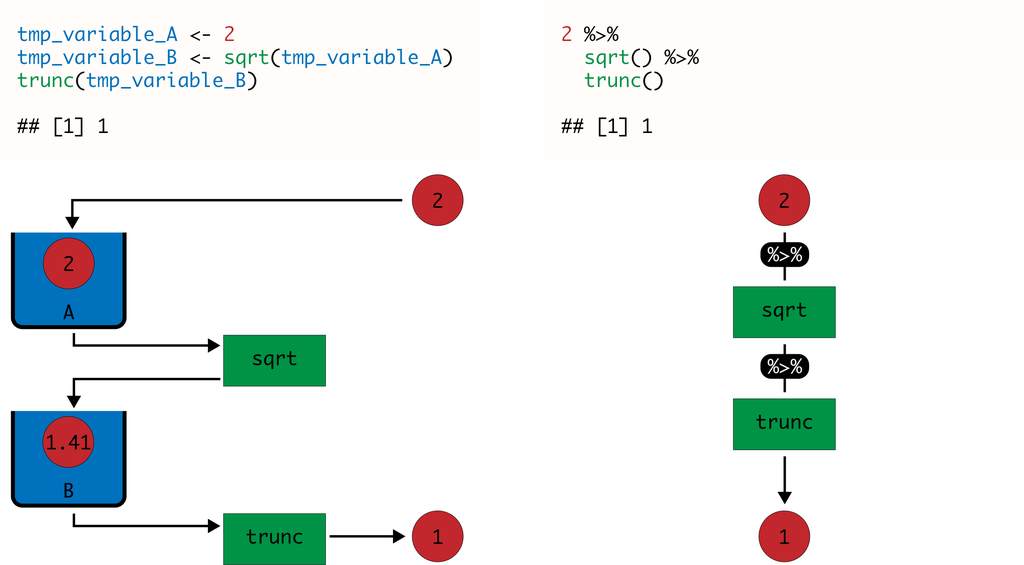

## Pipe example

The two codes below are equivalent

- the first simply invokes the functions
- the second uses the pipe operator `%>%`

```r
round(sqrt(2), digits = 2)
```

```
## [1] 1.41
```

```r
library(tidyverse)

sqrt(2) %>%
 round(digits = 2)
```

```
## [1] 1.41
```

## Coding style

A *coding style* is a way of writing the code, including

- how variable and functions are named
  - lower case and `_`
- how spaces are used in the code
- which libraries are used

```r
# Bad
X<-round(sqrt(2),2)

#Good
sqrt_of_two <- sqrt(2) %>%
 round(digits = 2)
```

Study the [Tidyverse Style Guid](http://style.tidyverse.org/) and use it consistently!

## Summary

An introduction to R

- The language
- Core concepts
- Tidyverse

**Next week**: Reproducible data science

- Reproducibility
- Read and write data
- Select and filter